Skip to contents

# `etable`: new features in `fixest` 0.10.2

Laurent Bergé

2026-03-18

Source: [`vignettes/etable_new_features.Rmd`](https://github.com/lrberge/fixest/blob/HEAD/vignettes/etable_new_features.Rmd)

This document illustrates the new features of `etable`, the tool to export estimation tables in `fixest`, in version 0.10.2.

## Preamble

Version 0.10.2 comes with majors changes in the Latex engine of `etable`. The most notable one is the ability to transform Latex tables into PNG files and display them either in RStudio’s viewer, either directly in HTML markdown documents (like all the tables in this document).

However, it requires that the following software are installed and work properly on the user-side:

- pdflatex (shipped in most Latex distributions) **or** the R package [`tinytex`](https://cran.r-project.org/package=tinytex) (very likely already installed),
- [imagemagick](https://www.imagemagick.org/) (to convert images) and [ghostscipt](https://www.ghostscript.com/) (to convert PDF files), **or** the R package [`pdftools`](https://cran.r-project.org/web/packages/pdftools/index.html).

Now we’re good to start. Let’s first define a global dictionary: it will rename the variables and will also include pre-defined notes that can be fetched from `etable`.

```r
library(fixest)
# Let's define a dictionary and set it globally.
# We also define notes, not just variable names.
# (The function 'dsb()' is like 'glue()' and is not important here.)
dict = c("(Intercept)" = "Constant",
         Petal.Length = "Petal length", Petal.Width = "Petal width",
         Sepal.Length = "Sepal length", Sepal.Width = "Sepal width",
         note1 = dsb("*Notes*: This is a note that illustrates how to access notes ",
                     "from the dictionary."),
         source = "*Sources*: Somewhere from the net.")
setFixest_dict(dict)
```

Then let’s define a few global options for the table. The philosophy is to set all the style components common across tables only once and for all thanks to `setFixest_etable`. The goal is, to increase maintainability, to use only table-specific arguments in later calls to `etable`. Hence, if the table style has to be changed, only one modification is needed (in `setFixest_etable`), and `etable` calls stay the same.

```r
# The style of the table
my_style = style.tex("aer", model.format = "(i)")

# markdown = TRUE is only useful in Rmarkdown documents
setFixest_etable(style.tex = my_style, markdown = TRUE, page.width = "a4")
```

The arguments `markdown` and `page.width` will be explained in the next section. And now the estimation we’ll use throughout this document.

```r
nm = names(iris)
est = feols(.[nm[1]] ~ .[nm[2:4]], iris, fsplit = ~Species)
```

## Displaying tables as PNG

One major improvement is the ability to generate PNG snapshots of Latex tables (I wish to thank Or Avishay-Rizi for the suggestion!). It works very intuitively: first a standalone Latex document is compiled to generate a PDF containing only the table, then imagemagick is used to convert the PDF into a PNG file. Note that image generation is not instantaneous because of the Latex compilation (but output can be cached, as explained later). These images are then accessible with the arguments `view` and `markdown`.

#### Argument `view`

In any call of `etable` (i.e. `tex = TRUE` is not required), on can use `view = TRUE` to display the table snapshot in Rstudio’s viewer. The table will fit the viewer’s window, being as large as possible without overflowing horizontally nor vertically.

This feature is, ironically, very hard to display in this document since there’s no viewer: so to see it at work, you should try it! Using the current example, just run `etable(est, view = TRUE)`.

Note that if the same tables are to be displayed several times, it can be useful to cache the PNG outputs to avoid the compilation run-time. To enable caching, use `setFixest_etable(view.cache = TRUE)`. The images are then saved in a temporary directory that the algorithm tries to find even across sessions – hence it enables long-term caching.

#### Argument `markdown`

This is a peculiar option that works only within `Rmarkdown` documents and is ignored otherwise. If `markdown = TRUE` the output becomes always a Latex table, even when `tex = FALSE` (default). Second, and most importantly, the output within the `Rmarkdown` document becomes contingent to the type of file generated. If the document is to be a PDF, then the code of a *regular Latex table* is returned. If the document is **not** a PDF (especially if it is an HTML file), then:

1. the PNG of the table is generated and saved in `images/etable/`, so that successive calls don’t need to re-generate the PNGs (i.e. this is caching),
2. the generated image is inserted in the document in an `<img>` tag,
3. that `<img>` tag is inserted in a `<div>` container of class `etable`.

This ensures that the tables are the same whether the output is a PDF or an HTML document. Since the table is embedded in a `<div>` container, you can even add some custom CSS to further customize how it looks.

All the images of the tables in this document are generated using `markdown = TRUE`, set globally in `setFixest_etable`.

#### Argument `page.width`

As mentioned, the tables are embedded in a standalone Latex document. The main consequence of this is that the table fits the PDF file completely, without any margin on any side. This means that whatever the width of the table (be it two or twenty columns), it will always take 100% of the width of the PDF.

While this property is fine when displaying on the viewer (since we usually want to see the full table), it makes the tables look odd and inconsistent in an HTML document. Indeed, since tables of two columns will take the same width as table of twenty columns, the font will look extra large for the former and extra small for the latter. That’s not something we usually want in a document.

Hence, here comes the `page.width` argument. This argument sets the width and side margins of the page in which will be inserted the table. The goal of this argument is to mimic the placement of the table in a *real* PDF document (i.e. in your article). This ensures that the PNG will look *as in* the PDF. For instance, `page.width = "a4"` will set an A4 page width and 2cm side margins on both sides. This argument can be customized at will: e.g. `8.5in, 1.1in` will lead to a page width of 8.5 inches with 1.1 inch side margins (the only constraint is that the unit of the width should be the same as the unit of the margin).

When `page.width` is set up, all tables in an HTML document will be consistent: the font will be the same across tables. On top of that, it also enables a couple of specific features. First, if the table is too narrow, you can use a *tabularx* table (with the argument `tabluar`) and the table will be as large as the “text” width (not the HTML text but the hypothetical PDF text). Second, if the table overflows, you can adjust it with the argument `adjustbox` to make it fit the text width.

## New Latex-escaping mechanism: Markdown markup and `makecell` support

Now almost any user-added text supports markdown markup for italics/bold/bold-italics with `*`, `**` and `***`. Further, there is native support for `makecell`: simply using `"\n"` enables it. Here’s an example:

```r
etable(est, headers = .("\n\n Short header" = 2, "*Very* \n **long** \n ***header***" = 2))
```

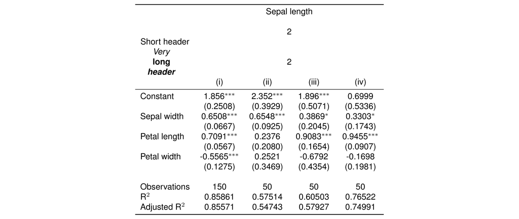

## Support for threeparttable notes

There is native support for the Latex package `threeparttable`. This option can be set via the function `style.tex()`. Further (and this is also new), you can access notes via the global dictionary to avoid repetitions:

```r
etable(est,
       style.tex = style.tex(tpt = TRUE, notes.tpt.intro = "\\footnotesize"),
       notes = c("note1", "source"))
```

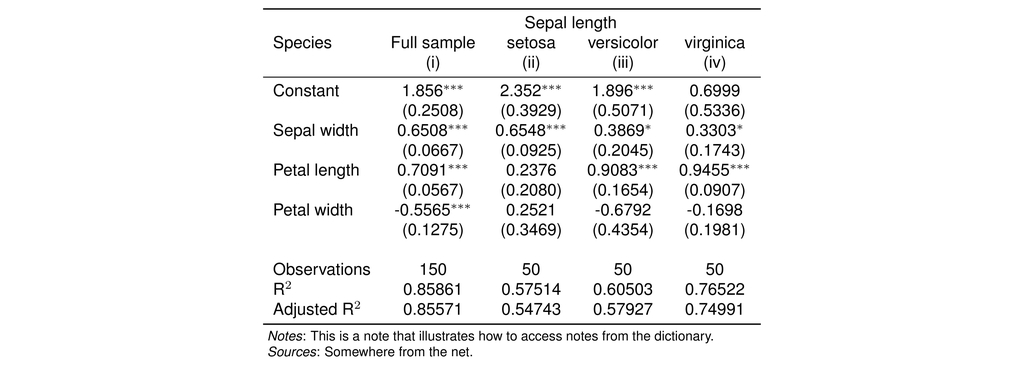

The table notes now are adjusted to the table width thanks to `threeparttable` and the notes are accessed directly with their keys. The argument `notes.tpt.intro` inserts Latex code right before the first `\\item` of threeparttable: in this case, it sets the font to `footnotesize`.

In general, it is advised to set the value of `tpt` and the `notes.tpt.intro` globally. Then if one wants to change the value of `notes.tpt.intro`, instead of typing `style.tex = style.tex(notes.tpt.intro = "stuff")`, the first element of `notes` will replace `notes.tpt.intro` if it starts with an `"@"`:

```r
# Setting up tpt globally
my_style = style.tex(tpt = TRUE,
                     notes.tpt.intro = "\\footnotesize")
setFixest_etable(style.tex = my_style)

# Below is identical to:
#  etable(est,
#         style.tex = style.tex(notes.tpt.intro = "\\Large"),
#         notes = "These notes are large.")
etable(est, notes = c("@\\Large", "These notes are large."))
```

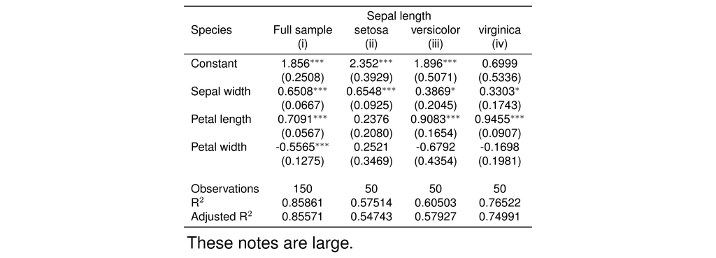

## Support for adjustbox

Now there is native support for the Latex package `adjustbox`. This nests the table into an `adjustbox` environment which will resize the image of the table at the appropriate dimensions, as provided by the user. This is especially useful for tables that overflow but can also be used to force a small table to fit a particular size.

By default if `adjustbox = TRUE`, the `adjustbox` environment is created with the options `width = 1\\textwidth, center`. This argument can be equal to a number, in which case it will be treated as the desired text width. Otherwise it accepts any character string.

Let’s have an example with a large table that would otherwise overflow:

```r
# mvsw == 'multiverse' stepwise (thanks to Resul Umit's suggestion)
est_many = feols(.[nm[1]] ~ mvsw(.[, nm[2:4]]), iris)
etable(est_many, adjustbox = 1.1)
```

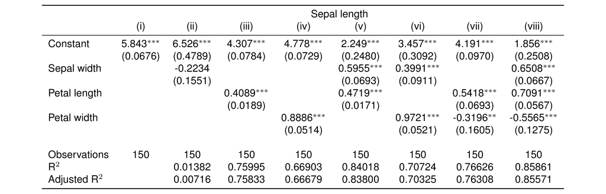

## Highlighting coefficients

Highlighting coefficients is often very useful, especially in presentations. There are now three main ways, natively implemented, to highlight the coefficients:

- using a frame,
- coloring the cells,
- giving a custom style to the coefficients.

The first two can be accessed via the `highlight` argument. The last is implemented in the `coef.style` argument.

#### Frame

By default, the `highlight` argument superimposes a frame around the coefficients of interest. This is done thanks to some `tickz` magic that I barely understand found in [tex stack exchange](https://tex.stackexchange.com/questions/240542/adding-a-rectangular-box-with-tikz-to-table-beamer).

Anyway, back to the argument. The syntax is `"options" = "coefficients location"`. The coefficient location can be expressed in several ways:

- the coefficient name: the full row is selected. Ex: `Petal.L` will select the `Petal.Length` row.
- the coefficient name followed by `@` and column ranges: in the coefficient row, only selects the given columns. Ex: `Petal.L@1,3-4` will select, in the row `Petal.Length`, the columns 1, 3 and 4.
- a vector of two coefficient cells: selects the full range from top-left to bottom right. Ex: `c("Petal.L@2", "Petal.W@3")` will select a range from the second column of `Petal.Length` to the third column of `Petal.Width`.

Let’s have an example illustrating the three ways to select the coefficients and some options. We also increase the row heights with `arraystretch` to facilitate the highlighting:

```r
etable(est, arraystretch = 1.5,
       highlight = .("Sepal@1",
                     "cyan4, square" = "Petal.L@3-4",
                     "thick5, sep8, darkgreen!90, se" = "Petal.W"))
```

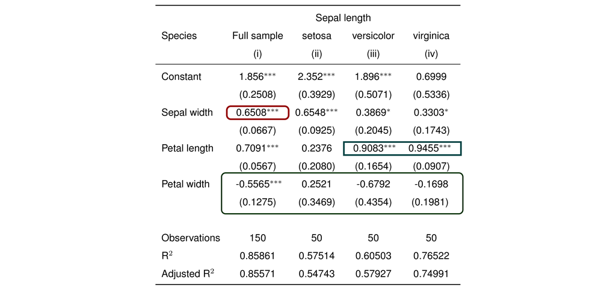

#### Row colors

Instead of highlighting coefficients with a frame, row color highlighting can be used. It is monitored with the same argument `highlight` and in fact you only have to add the option `rowcol` to make it work. Let’s replicate the previous example with row color:

```r
etable(est, arraystretch = 1.5,
       highlight = .(rowcol = "Sepal@1",
                     "rowcol, cyan4!70" = "Petal.L@3-4",
                     "rowcol, darkgreen!40, se" = "Petal.W"))
```

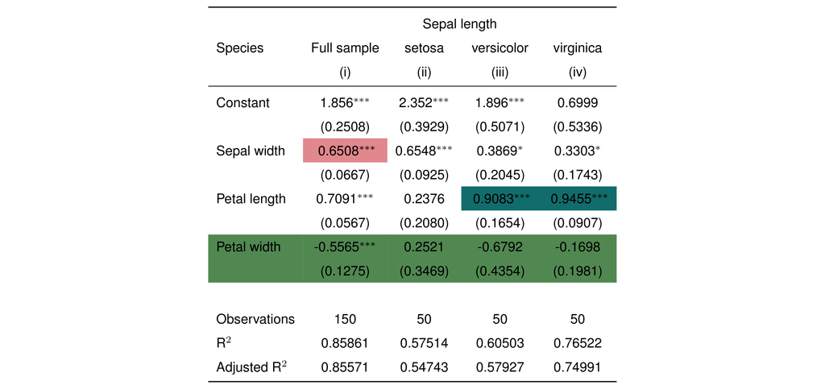

As opposed to the previous example, we only have increased the transparency of the colors with the `color!alpha` syntax.

Contrary to the frame, there are no options for the row coloring apart from the color itself and `se` to include the standard-errors.

#### Style

Using the same syntax as before to *select* the coefficients, it is possible to completely customize the coefficient cells. The syntax is `coef.style = .("style" = "coefficients location")` with style equal to Latex code containing the tag `:coef:` which will be replaced with the coefficient value. Alternatively, using the tag `:coef_se:` will apply the style both to the coefficient and the standard-error.

Here is the replication of the previous example with another highlighting:

```r
etable(est, coef.style = .(":coef:$\\bigstar$" = "Sepal@1",
                           "**:coef:**" = "Petal.L@3-4",
                           "\\color{BrickRed} :coef_se:" = "Petal.W"))
```

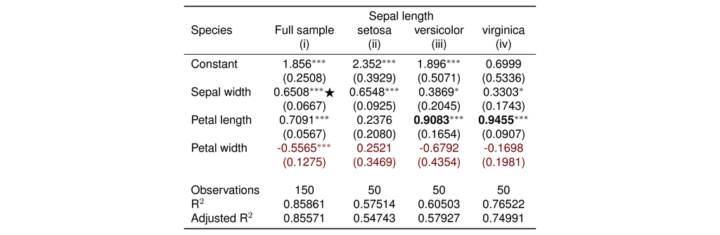

## CSS and co.

As already said, the image of the table is embedded in a `<div>` container whose default class is `etable`. You can set the class of that `<div>` manually with the argument `div.class`. And do things like that:

```css
/* This is CSS code */
.etable_box {
  border: 2pt solid;
  border-radius: 5px;
  box-shadow: 12px 12px 2px 1px rgba(0, 0, 255, .2);
  margin: 0 20% 2em 20%;
  padding: 1em;
}
```

```r
etable(est, div.class = "etable_box", page.width = "fit",
       title = "CSS illustration.")
```

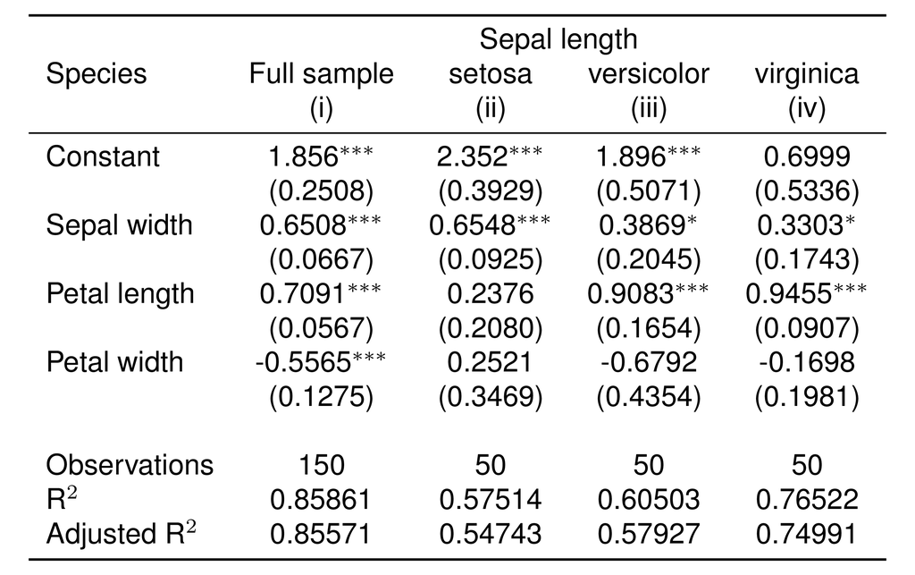

I’m not sure it should be done, but at least it’s possible!